# **Supplementary material 1:** How to bridge the last mile in agro-climate service adoption? The importance of farmers’ needs, attitudes and interpersonal relations

September 30, 2022

# 1. Method for testing impact pathway relationship

This document describes the process to develop an impact pathway and the testing function for a relationship between hypothesized cause and effect events. The document also contains the implementation of the test function for relations of events in the delivery and impact pathway of agro-climate services (ACS) in two farmers groups in Dien Bien, Vietnam. The testing is programmed with the `gsDesign` package (Anderson 2021). The full testing procedure is available in the [ACS-adoption-decision-pathway](https://github.com/ThiThuGiangLuu/ACS-adoption-decision-pathway/blob/master/Diffusion.R).

### a. Develop the conceptual impact pathways

We conceptualized the impact pathway based on different sources of information including the project’s design, project’s logical framework, innovation diffusion literature and personal communication with key informants from the project (see Figure below).

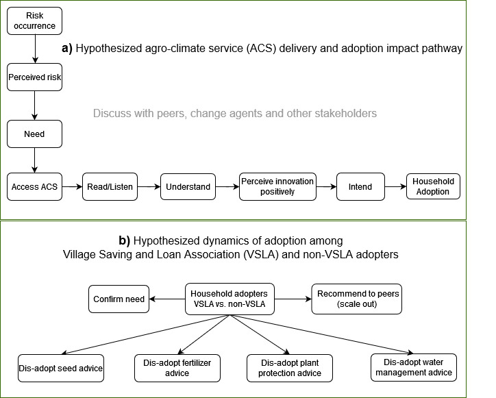

Figure: Hypothesized agro-climate service (ACS) delivery and adoption impact pathway and the dynamics of ACS adoption in Village saving and loan association (VSLA) and conventional farmer groups (non-VSLA) in Muong Phang and Pa Khoang communes, Dien Bien District, Vietnam

### b. Supplementary Information 2: Farmer survey

`SI2-Questionnaire.pdf` contains the set of questions used in the farmer survey, aiming for testing the conceptual impact pathways. Download the [Survey tool](https://github.com/ThiThuGiangLuu/ACS-adoption-decision-pathway/blob/master/SI2-Questionnaire.pdf).

### c. Supplementary information 3: Description of variables collected from farmer survey

`SI3-diffusion-variable-description.xlsx` contains data for general statistics and for testing. The tables contains information including name of variable; description of variable, type of variable values and which question is the questionnaire was used to get the data for that variable. Download the [Description table](https://github.com/ThiThuGiangLuu/ACS-adoption-decision-pathway/blob/master/SI3-diffusion-variable-description.xlsx).

### d. Supplementary information 4: Data table

The data table `diffusion.csv` contains surveyed data for general statistics and data used for testing. The table includes the variable names and its values. Download the [Data table](https://github.com/ThiThuGiangLuu/ACS-adoption-decision-pathway/blob/master/diffusion.csv).

We call the data file for analysis

```r
diffusion <- read.csv("diffusion.csv", header=TRUE)
```

### e. Development of the test function

The testing function `test_relationship` described in this document is programmed in the R programming language (R Core Team 2020). The testing function that is described here can also be found in the [ACS-adoption-decision-pathway](https://github.com/ThiThuGiangLuu/ACS-adoption-decision-pathway/blob/master/Diffusion.R).

The tests aim for validating relationships between hypothesized causal and resulting events, which are both binomially distributed. We do so by comparing the two “success” rates of the resulting event brought about in the presence and absence of the hypothesized causal event. The two success rates are calculated as the probability of observing successful event [yes] together with causal event [yes] observations and the probability to observe successful event [yes] observations together with causal event [no] observations. These observations are obtained from farmer survey sample.

We use the `ciBinomial` function in `gsDesign` package (Anderson 2021) to calculate the confidence interval (CI) of the difference between the two rates.

The test outcomes include the observation of both intervention and impact events, the success rates and the confidence intervals of the difference between the two success rates.

```r
test_relationship<-function(data, intervention, impact)
{

  # Intervention means causal event with [yes] observation
  # But for simplification, we call it "intervention".
  # intervention_subset: List all the impact observation under intervention condition
  # Check the return results in the global environment for more details of the calculation
  # Remove NAs value. Otherwise it will also count NA value as 1
  intervention_subset <- na.exclude(data[data[intervention]==1, impact] )

  # control_subset: List all the impact observation under control condition
  # control means causal variable with [no] observation. It might not really be control.
  # However, to make it simple, we call it "control".
  # Remove NAs value. Otherwise it will also count NA value as 0
  control_subset <- na.exclude(data[data[intervention]==0, impact] )

  #n of intervention. This length is also equal to the count of impact observation under intervention condition
  intervention_subset_n <- length(intervention_subset)

  #n of control. The length is also equal to the count of impact observations under control condition
  control_subset_n <- length(control_subset)

  #filtering for '1' to get success count
  intervention_subset_success <- length(which(intervention_subset==1))

  #filter for '1' to count success despite no intervention
  control_subset_success <- length(which(control_subset==1))


  #Confidence interval of likelihood of same outcome in control condition
  confinf<-ciBinomial(x1 = intervention_subset_success, #number of success in attributable to intervention
                      x2 = control_subset_success, #number of success attributable to control
                      n1 = intervention_subset_n, #length of impact observation under intervention
                      n2 = control_subset_n) #length of impact observation under control

   return(list(#n observation under all conditions
              total_n = intervention_subset_n+control_subset_n,
              # Return observations under intervention
              Intervention_subset=intervention_subset,
              #x1 for success under intervention
              x1_intervention_subset_success=intervention_subset_success,
              #n1 for all interventions
              n1_intervention_subset_n = intervention_subset_n,
              #rate of success for intervention group
              yes_rate_intervention_subset = length(which(intervention_subset==1))/(intervention_subset_n),
              # Return observations under control
              Control_subset=control_subset,
              #x2 for success under control
              x2_control_subset_success=control_subset_success,
              #n2 for all control
              n2_control_subset_n = control_subset_n,
              #rate of success despite no intervention
              yes_rate_control_subset = length(which(control_subset==1))/(control_subset_n),
              #Confidence intervals for rate of success in intervention condition compared with control condition
              CI = confinf ))
}
```

After obtaining the confidence interval value, we interpret the relation of the hypothesized causal and resulting events using our proposed procedure. The procedure aims at interpreting CI in a practical context. In this procedure, we compare CI with a pre-defined range of practical indifference. If the CI lays completely within the range of practical indifference, the difference was considered practically irrelevant or trivial. We also considered other possibilities of the CI value when compared with the range of practical indifference that might lead to other possible interpretations. Depending on the range of CI, we considered the hypothesized causal and resulting events to have no, potential, weak, moderate or strong relationships. We adapted the matrix of the strength of evidence by (Mcbride et al. 2013) and proposed our interpretation of CI for the difference of the two proportions (see below Figure).

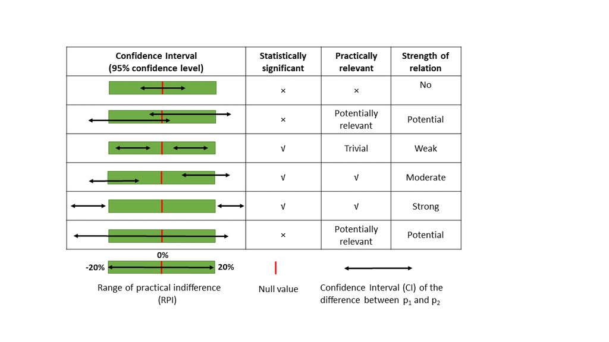

Figure: Quantification of the strength of relationships between binomially distributed (hypothesized) causal and resulting events. The quantification is based on the interpretation of a 95% confidence interval (CI) for the difference of the probabilities p1 and p2 of the “successful event” [yes] attributable to [yes] and [no] observations of the hypothesized causal event. The width of the CI is compared with a pre-defined range of practical indifference. Depending on the range of the CI, we considered the hypothesized causal and resulting events to have no, potential, weak, moderate or strong relationships. Source: Adapted from McBride et al. (2013)

### f. Implement the test for the agro-climate service delivery and adoption impact pathway

We test the relations of each sub-hypothesis described in the hypothesized ACS delivery and adoption impact pathway using testing function `test_relationship`. For example, we test the difference between access rate among village saving and loan association (VSLA) farmers needing and not needing ACS in the following function.

```r
# Subsetting VSLA data for analysis

vsla<-subset(diffusion,VSLA=="1")

# Implement testing function

vslaneed_access <- test_relationship(vsla,"need","access")
```

Below is the test outcomes of the relationship between “need” and “access”, in which

| Test outcomes | Meaning |
| --- | --- |
| total_n | total observations of “access” in all “need[yes]” and “need[no] conditions” |
| Intervention_subset | list all the “access[yes]” and “access[no]”observation in the presence of “need[yes]” |
| x1_intervention_subset_success | number of “access[yes]” attributable to “need[yes]” (x1) |
| n1_intervention_subset_n | length of intervention_subset (n1) |
| yes_rate_intervention_subset | successful “access” rate in the presence of “need[yes]” (x1/n1) |
| Control_subset | list all the “access[yes]” and “access[no]”observation in the presence of “need[no]” |
| x2_control_subset_success | number of “access[yes]” attributable to “need[no]” (x2) |
| n2_control_subset_n | length of control_subset (n2) |
| yes_rate_control_subset | successful “access” rate in the presence of “need[no]” (x2/n2) |
| CI | Confidence interval of “access” rate difference between VSLA farmers who have “need” and VSLA farmers without “need” |

```
## $total_n
## [1] 40
##
## $Intervention_subset
##  [1] 1 1 1 1 1 1 1 1 1 1 1 1 1 1 1 1 1 1 1 1 1 1 1 1 1 1 1 1 1 1
## attr(,"na.action")
## [1] 1
## attr(,"class")
## [1] "exclude"
##
## $x1_intervention_subset_success
## [1] 30
##
## $n1_intervention_subset_n
## [1] 30
##
## $yes_rate_intervention_subset
## [1] 1
##
## $Control_subset
##  [1] 1 1 1 1 1 1 1 1 1 1
## attr(,"na.action")
## [1] 1
## attr(,"class")
## [1] "exclude"
##
## $x2_control_subset_success
## [1] 10
##
## $n2_control_subset_n
## [1] 10
##
## $yes_rate_control_subset
## [1] 1
##
## $CI
##       lower     upper
## 1 -0.113509 0.2775562
```

### g. Supplementary Information 5: R code of the model testing

```r
library(ggplot2)
library(gsDesign)


#Function to test difference of the two binomial rates
#Ref. Eike's function to test relationship----

test_relationship<-function(data, intervention, impact)
{

  # Intervention means hypothesized causal event with [yes] observation
  # But for simplification, we call it "intervention".
  # intervention_subset: List all the impact observation under intervention condition
  # Check the return results in the global environment for more details of the calculation
  # Remove NAs value. Otherwise it will also count NA value as 1
  intervention_subset <- na.exclude(data[data[intervention]==1, impact] )

  # control_subset: List all the impact observation under control condition
  # control means causal variable with [no] observation. It might not really be control.
  # However, to make it simple, we call it "control".
  # Remove NAs value. Otherwise it will also count NA value as 0
  control_subset <- na.exclude(data[data[intervention]==0, impact] )

  #n of intervention. This length is also equal to the count of impact observation under intervention condition
  intervention_subset_n <- length(intervention_subset)

  #n of control. The length is also equal to the count of impact observations under control condition
  control_subset_n <- length(control_subset)

  #filtering for '1' to get success count
  intervention_subset_success <- length(which(intervention_subset==1))

  #filter for '1' to count success despite no intervention
  control_subset_success <- length(which(control_subset==1))


  #Confidence interval of likelihood of same outcome in control condition
  confinf<-ciBinomial(x1 = intervention_subset_success, #number of success in attributable to intervention
                      x2 = control_subset_success, #number of success attributable to control
                      n1 = intervention_subset_n, #length of impact observation under intervention
                      n2 = control_subset_n) #length of impact observation under control


  return(list(#n observation under all conditions
              total_n = intervention_subset_n+control_subset_n,
              # Return observations under intervention
              Intervention_subset=intervention_subset,
              #x1 for success under intervention
              x1_intervention_subset_success=intervention_subset_success,
              #n1 for all interventions
              n1_intervention_subset_n = intervention_subset_n,
              #rate of success for intervention group
              yes_rate_intervention_subset = length(which(intervention_subset==1))/(intervention_subset_n),
              # Return observations under control
              Control_subset=control_subset,
              #x2 for success under control
              x2_control_subset_success=control_subset_success,
              #n2 for all control
              n2_control_subset_n = control_subset_n,
              #rate of success despite no intervention
              yes_rate_control_subset = length(which(control_subset==1))/(control_subset_n),
              #Confidence intervals for rate of success in intervention condition compared with control condition
              CI = confinf ))
}

# error checkRange: Error in checkRange(x, ..., varname = deparse(substitute(x))) : n1 not on interval [1, Inf]
# can not return result if there is no "control"n1=0 or "experiment"n2=0,

#Subsetting data for analysis####
diffusion <- read.csv("diffusion.csv", header=TRUE)
#VSLA dataset####
vsla<-subset(diffusion,VSLA=="1")
#write.csv(vsla, "vsla-table.csv")

#non-VSLA dataset####
nonvsla<-subset(diffusion,VSLA=="0")
#write.csv(nonvsla, "nonvsla-table.csv")
#
vsla$total_adopt
nonvsla$total_adopt
#Subset VSLA and non-VSLA who adopted ACIS: to analyze dynamics of adoption####
adopt<-subset(diffusion, total_adopt=="1")
vslaadopt<-subset(adopt,VSLA=="1")
nonvslaadopt<-subset(adopt,VSLA=="0")

#I. VSLA and non-VSLA testing: Adopting pathway####
#Subset VSLA data
vsla<-subset(diffusion,VSLA=="1")

#1.1 VSLA TESTING risk occurrence and risk perception----

vsladisaster_perception <- test_relationship(vsla,"risk","risk_impact")

#1.2 Non-VSLA TESTING risk occurrence and risk perception----

nonvslarisk_perception <- test_relationship(nonvsla,"risk","risk_impact")

#2.1 VSLA TESTING risk impact and need----

vslarisk_need <- test_relationship(vsla,"risk_impact","need")

#2.2 Non VSLA TESTING risk impact and need----

nonvslarisk_need <- test_relationship(nonvsla,"risk_impact","need")

#3.1 VSLA TESTING need and access----

vslaneed_access <- test_relationship(vsla,"need","access")

#3.2 nonVSLA TESTING need and access----

nonvslaneed_access <- test_relationship(nonvsla,"need","access")
#4.1 VSLA TESTING access and total read_listen----

vslaaccess_totalreadlisten <- test_relationship(vsla,"access","total_readlisten")

#4.2.NonVSLA TESTING access and total read_listen----

nonvslaaccess_totalreadlisten <- test_relationship(nonvsla,"access","total_readlisten")


#5.1 VSLA TESTING total read_listen and total discuss----

vslatotalreadlisten_discuss <- test_relationship(vsla,"total_readlisten", "total_discuss")

#5.2 nonVSLA TESTING total read_listen and total discuss----

nonvslatotalreadlisten_discuss <- test_relationship(nonvsla,"total_readlisten", "total_discuss")


#6.1 VSLA TESTING total discuss and total understand----

vsla_total_discuss_understand <- test_relationship(vsla, "total_discuss","total_understand")


#6.2 NonVSLA TESTING total discuss and total understand----

nonvsla_total_discuss_understand <- test_relationship(nonvsla, "total_discuss","total_understand")

#7.1 VSLA TESTING total read_listen and total_understand----

vsla_total_readlisten_understand <- test_relationship(vsla, "total_readlisten","total_understand")

#7.2 nonVSLA TESTING total read_listen and total_understand----

nonvsla_total_readlisten_understand <- test_relationship(nonvsla, "total_readlisten","total_understand")


#8.1 VSLATESTING total understand and total perceive ACS positively----

vsla_total_understand_totalposper <- test_relationship(vsla, "total_understand", "total_posperception")

#8.2 nonVSLATESTING total understand and total perceive ACS positively----

nonvsla_total_understand_totalposper <- test_relationship(nonvsla, "total_understand", "total_posperception")

#9.1 VSLATESTING total perceive ACS positively and total intention to apply----

vsla_total_posper_intention <- test_relationship(vsla, "total_posperception", "total_intention")


#9.2 Non-VSLA TESTING total perceive ACS positively and total decide to apply----

nonvsla_total_posper_intention <- test_relationship(nonvsla, "total_posperception", "total_intention")


#10.1 VSLATESTING intention to adopt and total adoption----

vsla_total_intention_adopt <- test_relationship(vsla, "total_intention", "total_adopt")

#10.2 non-VSLATESTING intention to adopt and total adoption----

nonvsla_total_intention_adopt <- test_relationship(nonvsla, "total_intention", "total_adopt")

#II. Dynamics of adoption####

#1.TESTING VSLA and confirm need among adopters----

#Subset VSLA and non-VSLA who adopted ACS only
adopt<-subset(diffusion, total_adopt=="1")
vsla_confirm2 <- test_relationship(adopt,"VSLA","confirm_need2")

#2.TESTING VSLA and scale-out (recommendation)----

vsla_recommend <- test_relationship(adopt,"VSLA","recommend")

#3. What advice do farmers dis-adopt####
# Seed dis-adoption
seed_disadoption<-ciBinomial(15, 17, 38, 38, alpha = 0.05, adj = 0, scale = "Difference")
#-26-16%#
fertilizer_disadoption<-ciBinomial(9, 4, 39, 36, alpha = 0.05, adj = 0, scale = "Difference")
#-5-29%#
plant_protection_disadoption<-ciBinomial(8, 8, 39, 37, alpha = 0.05, adj = 0, scale = "Difference")
#-19-17%#
water_management_disadoption<-ciBinomial(15, 12, 39, 38, alpha = 0.05, adj = 0, scale = "Difference")
#-14-27%#
```

Download the [R code](https://github.com/ThiThuGiangLuu/ACS-adoption-decision-pathway/blob/master/Diffusion.R).

### h. Supplementary Information 6: Impact pathway validation and detailed results of the testing

The household survey served to validate the hypothesized ACS delivery and adoption impact pathway. The results show that the adoption impact pathways vary in VSLA and non-VSLA groups (below Figure)

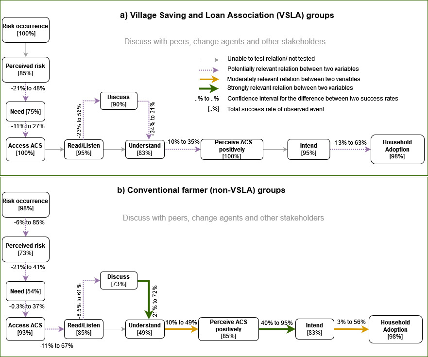

Figure: Testing results of an impact pathway describing the farmer’s decision-making processes in adopting agro-climate services in Muong Phang and Pa Khoang communes, Dien Bien District, Vietnam

In addition to the adoption impact pathway results, our survey also revealed some differences in attitudes and behaviour between VSLA and non-VSLA adopters

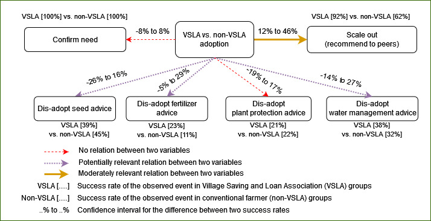

Figure: Testing results of the dynamics of agro-climate service adoption among Village Saving and Loan Association (VSLA) groups and non-VSLA groups in Muong Phang and Pa Khoang communes, Dien Bien District, Vietnam

`SI6-detailed results of the tests.pdf` contains detailed results of all the tests. Download the [Detailed Results](https://github.com/ThiThuGiangLuu/ACS-adoption-decision-pathway/blob/master/SI6-detailed%20results%20of%20the%20tests.pdf).

# 2. Acknowledgements

We acknowledge the valuable support from CARE International in Vietnam and the Centre for Community Development in Dien Bien. We are especially grateful for the support by Ms. Huong Tong from the Centre for Community Development in Dien Bien and other local collaborators for their excellent support in arranging interviews in Dien Bien. This research would not have been possible without the active participation of the farmers who were willing to share their personal experiences in using agro-climate services. The views expressed in this study are those of the authors and do not necessarily reflect the views of CARE International in Vietnam or the Centre for Community Development in Dien Bien.

We sincerely thank the Schlumberger Foundation for providing financial support for this study and a scholarship for the lead author through the Faculty for the Future Program.

# 4. References

Anderson, Keaven. 2021. “gsDesign: Group Sequential Design.” https://CRAN.R-project.org/package=gsDesign.

Mcbride, Graham, Russell Cole, Ian Westbrooke, and Ian Jowett. 2013. “Assessing Environmentally Significant Effects: A Better Strength-of-Evidence Than a Single P Value?” *Environmental Monitoring and Assessment* 186 (December). https://doi.org/10.1007/s10661-013-3574-8.

R Core Team. 2020. “R: A Language and Environment for Statistical Computing.” Vienna, Austria: R Foundation for Statistical Computing. https://www.R-project.org/. https://www.R-project.org/.